# Dissolved Oxygen Clean

Chelsey Wegener

11/3/2020

Cleaning up environmental dissolved oxygen data: Going to remove flagged data first and then hopefully I can use a 7 day rolling mean window to remove outliers. Using rolling mean to remove data points that are +/- 2 standard deviations away from mean.

```r
rm(list=ls())
library(tidyverse)
library(ggpubr)
library(scales)
library(chron)
library(plotly)
library(taRifx)
library(aweek)
library(easypackages)
library(renv)
library(here)
library(ggthemes)
library(gridExtra)
library(patchwork)
library(tidyquant)
library(recipes)
library(cranlogs)
library(knitr)
library(openair)
```

Make custom function

```r
custom_stat_fun_2<-function(x, na.rm=TRUE){
  m<-mean(x, na.rm=TRUE)
  s<- sd(x, na.rm=TRUE)
  hi<-m+2*s
  lo<-m-2*s
  ret<-c(mean=m, stdev=s, hi.95=hi, lo.95=lo)
}
```

**China Camp**

Read in and plot raw data

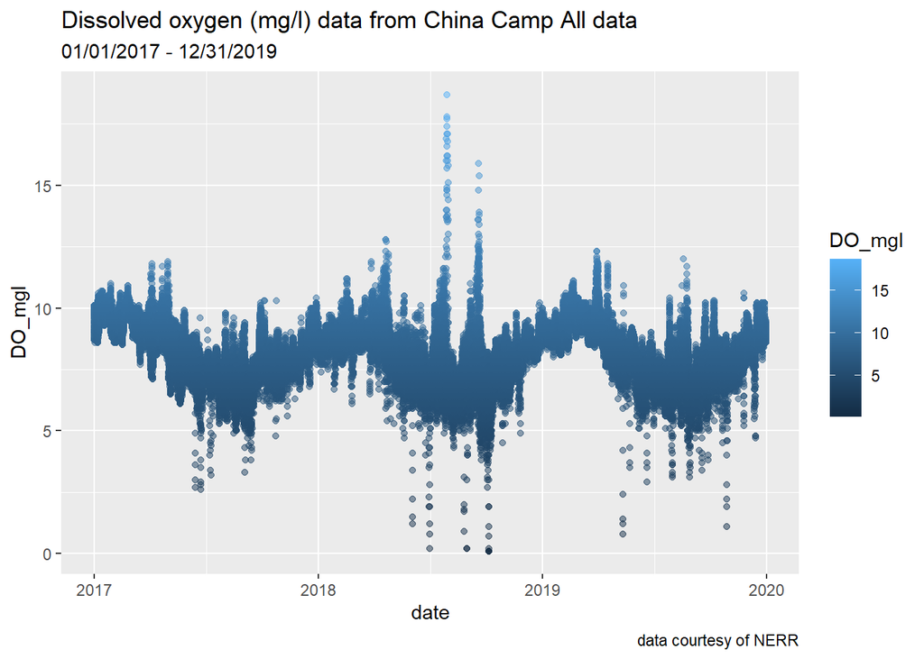

```r
cc<-read.csv("C:/Users/chels/Box Sync/Thesis/Data/Working data/Bouy data/china_camp_all.csv", header = TRUE, sep=",", fileEncoding="UTF-8-BOM", stringsAsFactors = FALSE)

cc$date<-as.Date(cc$DateTimeStamp, format = c("%m/%d/%Y"))

cc_raw<-cc%>%
  ggplot(aes(x=date, y=DO_mgl, color=DO_mgl))+
  geom_point(alpha=0.5)+
  labs(title="Dissolved oxygen (mg/l) data from China Camp All data",
       subtitle="01/01/2017 - 12/31/2019",
       caption= "data courtesy of NERR")
cc_raw
```

Remove flagged data

```r
cc<-cc[- grep("-3", cc$F_DO_mgl),]
```

7 day window rolling mean

```r
cc_week<-cc%>%
  tq_mutate(
    select= DO_mgl,
    mutate_fun= rollapply,
    width= 672,
    align= "right",
    by.column= FALSE,
    FUN= custom_stat_fun_2,
    na.rm= TRUE)
```

Filter and graph. Top=all data, bottom = filtered

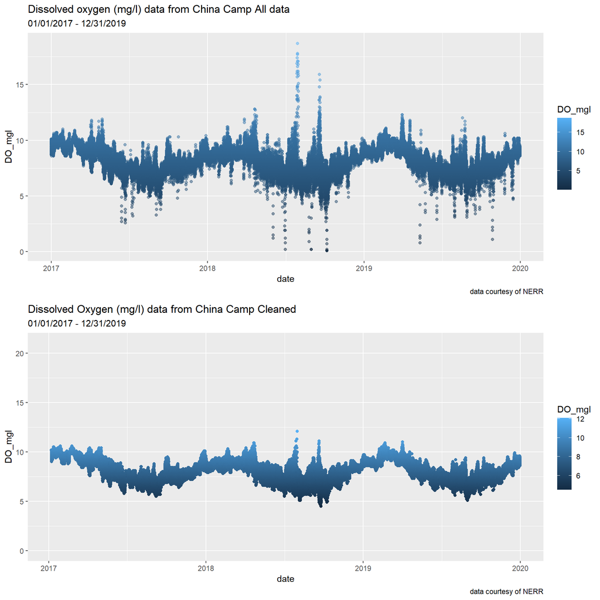

```r
cc_clean_data<-filter(cc_week, DO_mgl <hi.95 & DO_mgl >lo.95)

cc_clean<- ggplot(data = cc_clean_data, mapping = aes(x = date, y = DO_mgl, color=DO_mgl)) + geom_point()+ylim(0,21)+
  labs(title="Dissolved Oxygen (mg/l) data from China Camp Cleaned",
       subtitle="01/01/2017 - 12/31/2019",
       caption= "data courtesy of NERR")

ggarrange(cc_raw, cc_clean, ncol=1, nrow=2)
```

**EOS** Read in data

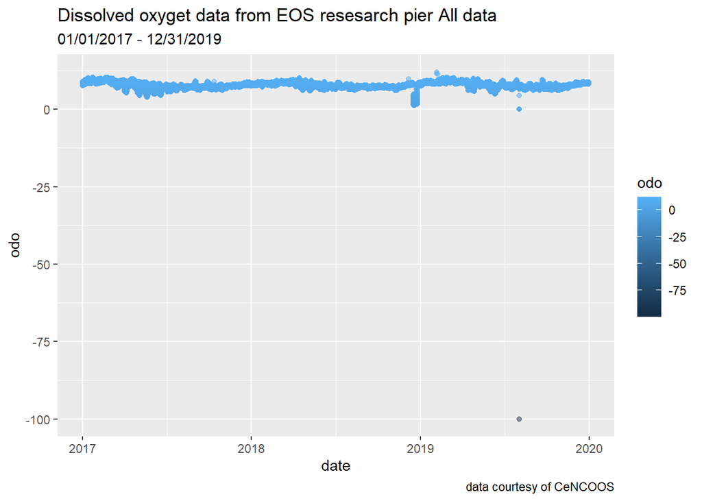

```r
eos<-read.csv("C:/Users/chels/Box Sync/Thesis/Data/Working data/Bouy data/eos_bouy_r.csv", header = TRUE, sep=",", fileEncoding="UTF-8-BOM", stringsAsFactors = FALSE)

eos$date<-as.Date(eos$date, format = c("%m/%d/%Y"))

eos_all<-eos%>%
  ggplot(aes(x=date, y=odo, color=odo))+
  geom_point(alpha=0.5)+
  labs(title="Dissolved oxyget data from EOS resesarch pier All data",
       subtitle="01/01/2017 - 12/31/2019",
       caption= "data courtesy of CeNCOOS")
eos_all
```

Remove flagged data–> don’t see QC test for this data set. Going to remove extreme/unlikely values

```r
eos<-filter(eos, odo >0)
```

Rolling 7 day mean:

```r
eos_week<-eos%>%
  tq_mutate(
    select= odo,
    mutate_fun= rollapply,
    width= 1680,
    align= "right",
    by.column= FALSE,
    FUN= custom_stat_fun_2,
    na.rm= TRUE)
```

Filter and graph. Top=all, bottom = filtered

```r
eos_clean_data<-filter(eos_week, odo <hi.95 & odo >lo.95)

eos_clean<- ggplot(data = eos_clean_data, mapping = aes(x = date, y = odo, color=odo)) + geom_point()+ylim(0,21)+
  labs(title="Dissolved oxygen data from EOS resesarch pier Cleaned",
       subtitle="01/01/2017 - 12/31/2019",
       caption= "data courtesy of CeNCOOS")

ggarrange(eos_all, eos_clean, ncol= 1, nrow = 2)
```

[figure not shown]

The extreme low DO towards the end of 2018 looks suspicious.Might filter out all values below 5 which would get rid of it since no others values do that low. Not sure if this is a true event or not.

**Richardson Bay**

Read in data

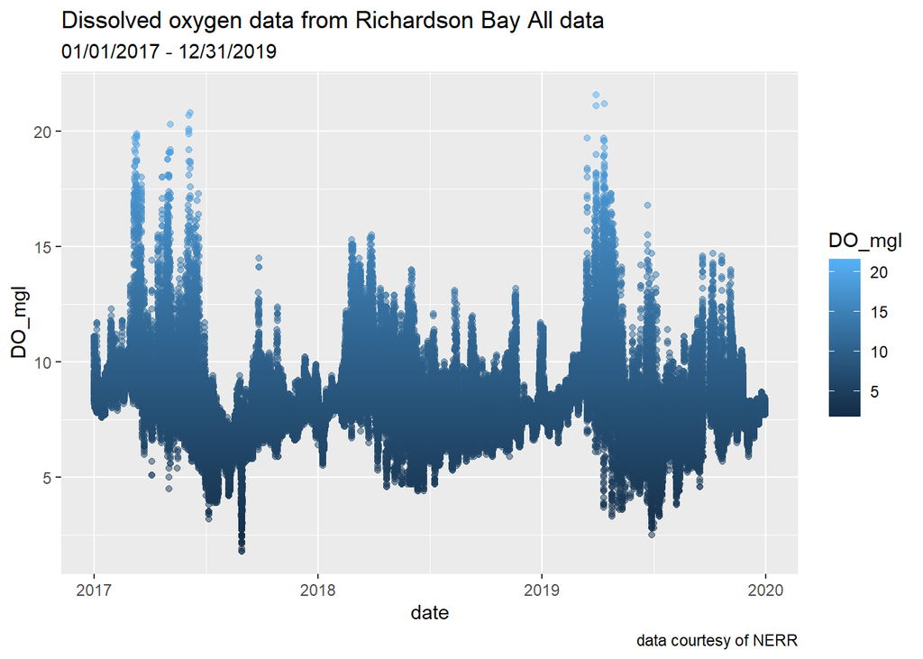

```r
rb<-read.csv("C:/Users/chels/Box Sync/Thesis/Data/Working data/Bouy data/richardson_bay_all.csv", header = TRUE, sep=",", fileEncoding="UTF-8-BOM", stringsAsFactors = FALSE)

rb$date<-as.Date(rb$DateTimeStamp, format = c("%m/%d/%y %H:%M"))

rb_all<-rb%>%
  ggplot(aes(x=date, y=DO_mgl, color=DO_mgl))+
  geom_point(alpha=0.5)+
  labs(title="Dissolved oxygen data from Richardson Bay All data",
       subtitle="01/01/2017 - 12/31/2019",
       caption= "data courtesy of NERR")
rb_all
```

```r
rb<-rb[- grep("-3", rb$F_DO_mgl),]
```

7 day rolling mean

```r
rb_week<-rb%>%
  tq_mutate(
    select= DO_mgl,
    mutate_fun= rollapply,
    width= 672,
    align= "right",
    by.column= FALSE,
    FUN= custom_stat_fun_2,
    na.rm= TRUE)
```

Filter and graph. Top = all, bottom = filtered

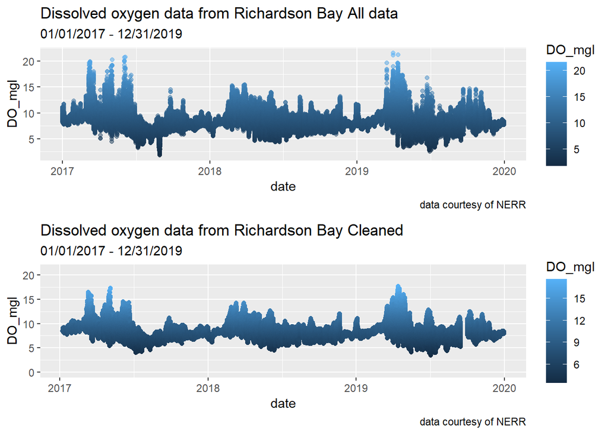

```r
rb_clean_data<-filter(rb_week, DO_mgl <hi.95 & DO_mgl >lo.95)


rb_clean<- ggplot(data = rb_clean_data, mapping = aes(x = date, y = DO_mgl, color=DO_mgl)) + geom_point()+ylim(0,21)+
  labs(title="Dissolved oxygen data from Richardson Bay Cleaned",
       subtitle="01/01/2017 - 12/31/2019",
       caption= "data courtesy of NERR")

ggarrange(rb_all, rb_clean, ncol= 1, nrow = 2)
```

**Fort Point**

No dissolved oxygen data available

**All together**

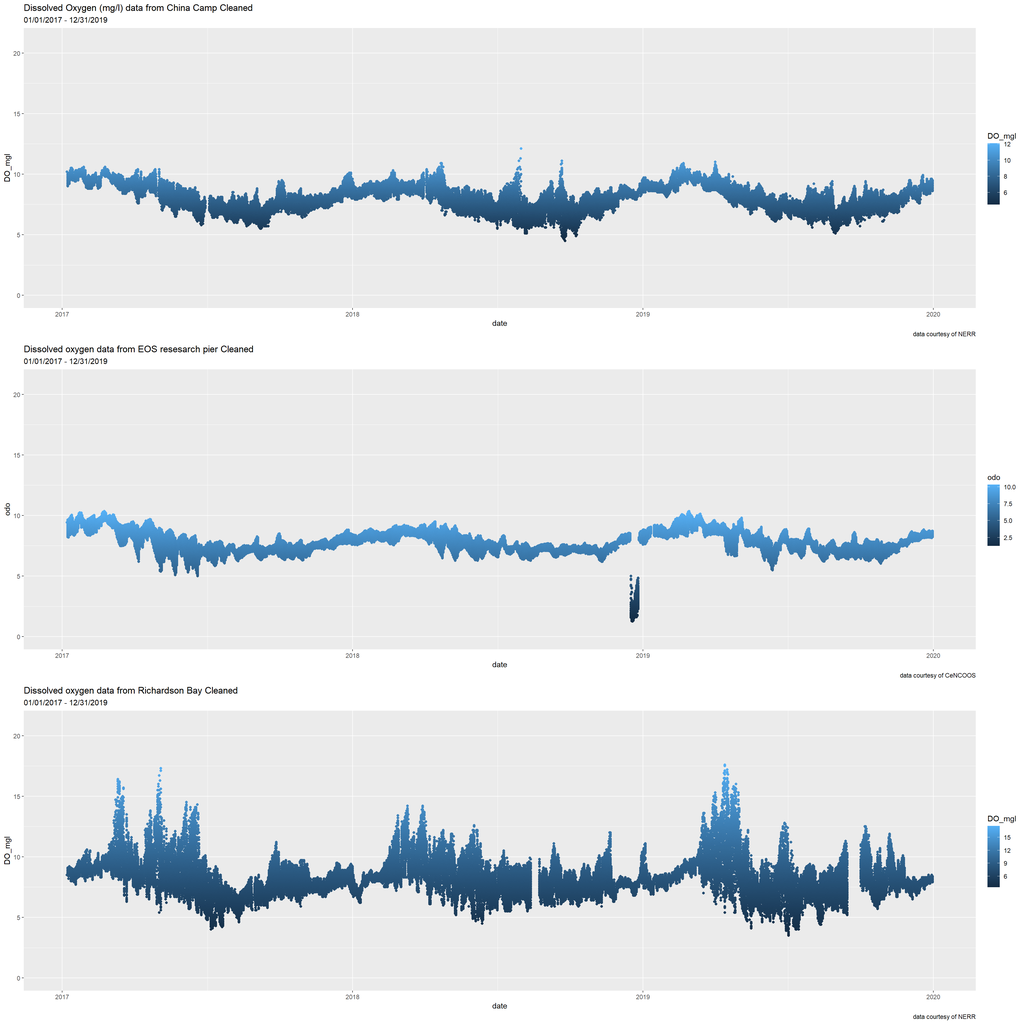

```r
ggarrange(cc_clean, eos_clean, rb_clean, nrow=3, ncol=1)
```